# Notebook 01: Language of Predictive Models

```r
library(tidyverse)
library(forcats)
library(ggrepel)
library(smodels)

theme_set(theme_minimal())
options(dplyr.summarise.inform = FALSE)
options(width = 77L)
```

## Tea Reviews

We are going to start by looking at a data set of tea reviews. Specifically, tea reviews from the [Adagio Tea](http://www.adagio.com/) website. I collected this data set a few years ago, so it should be similar but not exactly the same as what is one the site today. Let’s read the data into R:

```r
tea <- read_csv(file.path("data", "tea.csv"))
tea
```

```
## # A tibble: 238 x 5
##    score name                type  price num_reviews
##    <dbl> <chr>               <chr> <dbl>       <dbl>
##  1    96 irish_breakfast     black    10        3675
##  2    95 earl_grey_bravo     black    10        3520
##  3    95 golden_monkey       black    27        1125
##  4    96 black_dragon_pearls black    32        1748
##  5    95 yunnan_noir         black    17         988
##  6    95 earl_grey_moonlight black    10        2510
##  7    93 english_breakfast   black    17        1008
##  8    92 keemun_concerto     black    17         499
##  9    95 yunnan_gold         black    40        1094
## 10    94 ceylon_sonata       black    12        1525
## # … with 228 more rows
```

Looking at the data in the data viewer, we see several variables. The goal is to predict the user score of each tea.

Variables available to predict the output are the type of tea, the number of reviews received the price of the tea. The latter is given in estimated cents per cup as reported on the site. We also have the full name of the tea, though that will not be very useful for prediction.

## Exploratory analysis

### Univariate plots

Before doing anything else, we will do some exploratory data analysis:

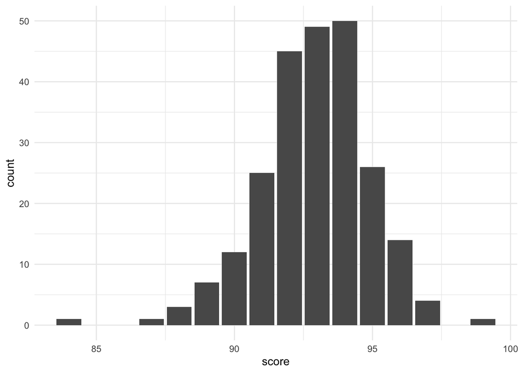

```r
tea %>%
  ggplot(aes(x = score)) +
    geom_bar()
```

The score values are generally very high, with most of them above 88. All of the scores are whole integers, and the most common values are between 92 and 95.

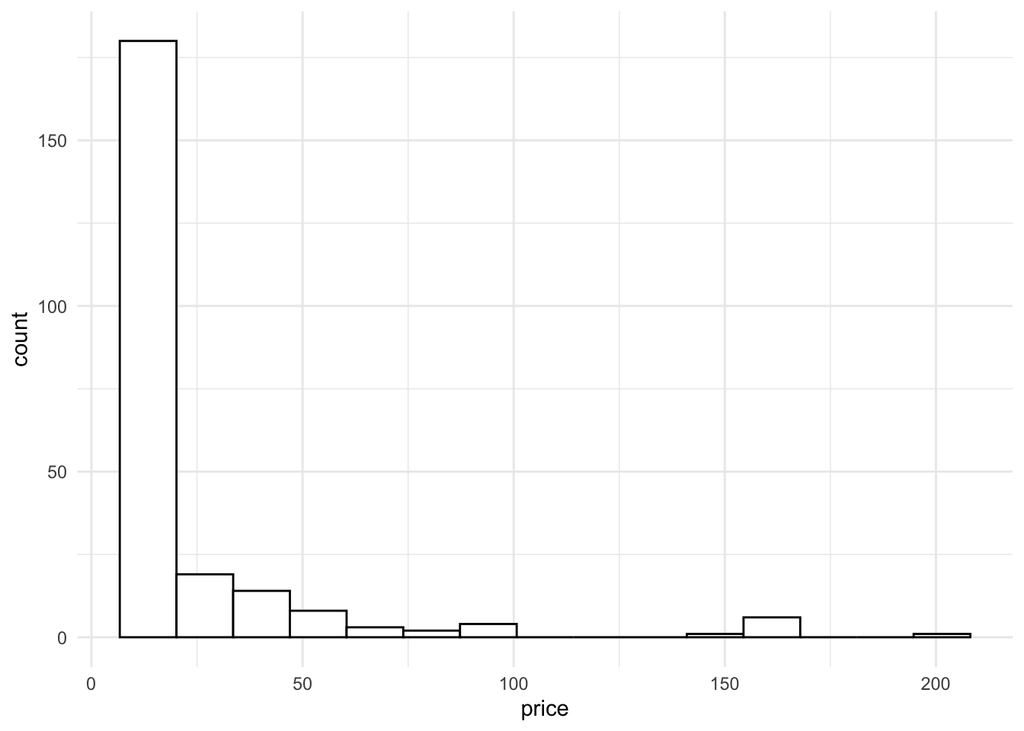

```r
tea %>%
  ggplot(aes(x = price)) +
    geom_histogram(bins = 15, color = "black", fill = "white")
```

The price variable is heavily skewed, with a few very expensive teas. Most are well under a quarter per cup.

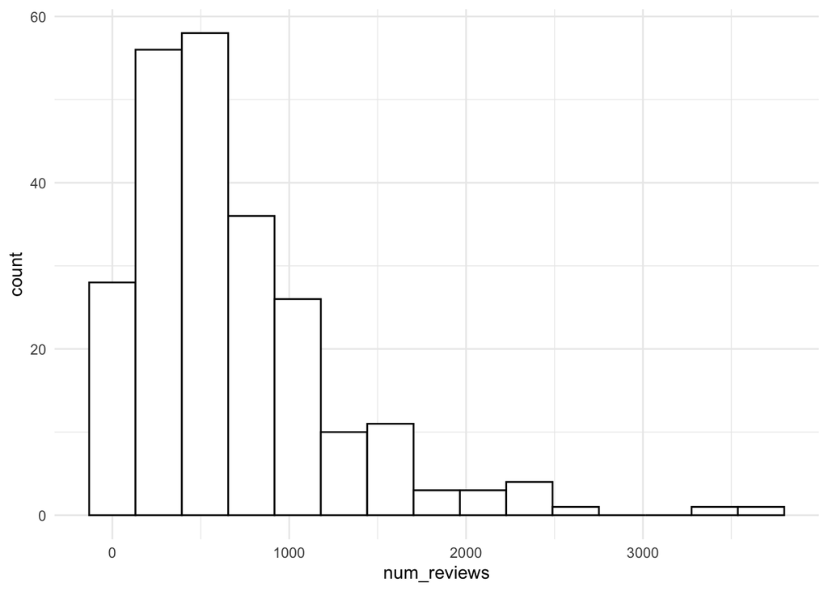

```r
tea %>%
  ggplot(aes(x = num_reviews)) +
    geom_histogram(bins = 15, color = "black", fill = "white")
```

The number of reviews also have a bit of skew, but not as strongly as the price variable.

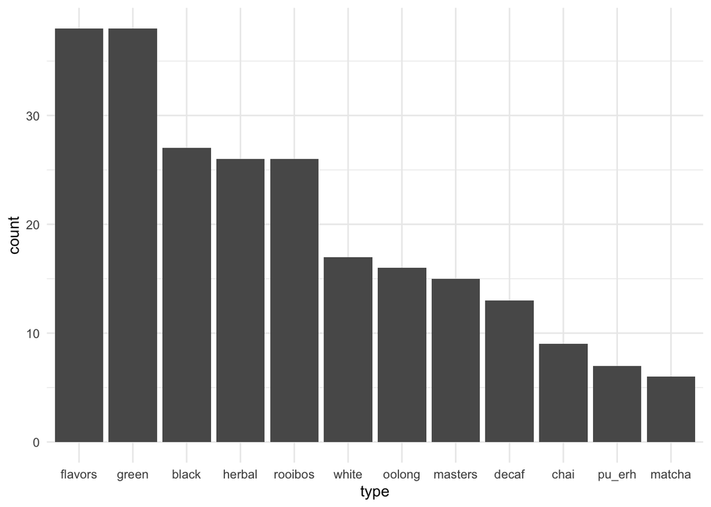

```r
tea %>%
  group_by(type) %>%
  summarise(sm_count()) %>%
  arrange(desc(count)) %>%
  mutate(type = fct_inorder(type)) %>%
  ggplot(aes(x = type, count)) +
    geom_col()
```

There are twelve types of tea, with some having only a few samples and others having over thirty.

### Bivariate plots

Now, we can proceed to bi-variate plots showing the relationship between each variable and the response.

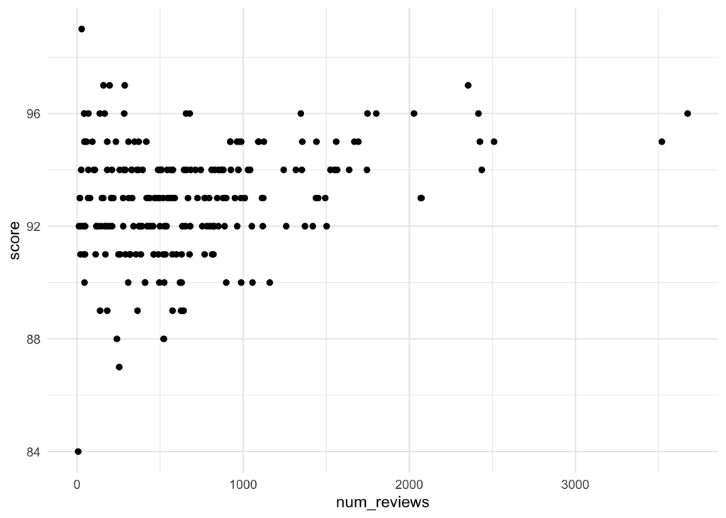

```r
tea %>%
  ggplot(aes(num_reviews, score)) +
    geom_point()
```

There seems to be a slight positive relationship between the number of reviews and the score.

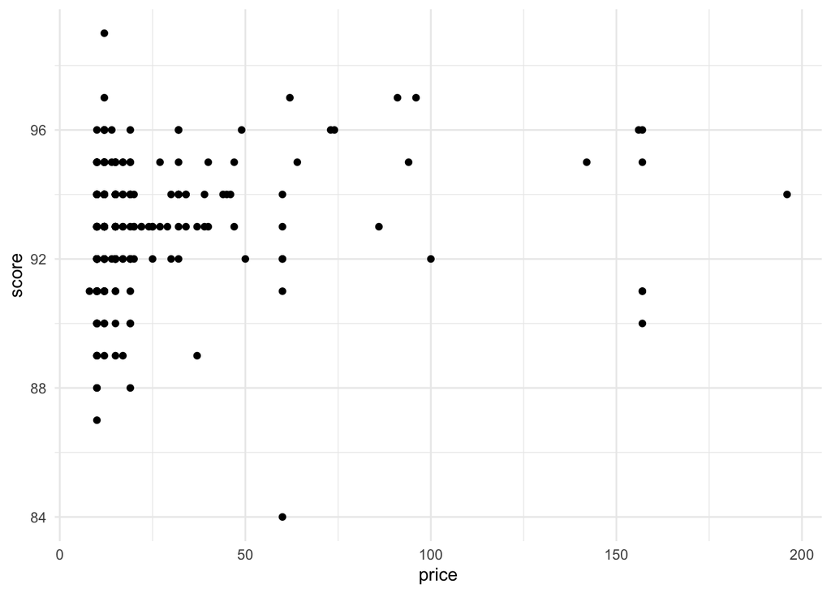

```r
tea %>%
  ggplot(aes(price, score)) +
    geom_point()
```

Given the skew of the plot, it is hard to figure out the exact relationship between price and score.

## Linear Models

The classical linear regression model assumes that the average value, or mean, of the response Y is a linear function of X. Symbolically, with the index i representing the i’th sample, this gives:

$$\text{mean} (Y_i) = \alpha + \beta * X_i$$

Similarly, we can write that Y is equal to a fixed linear effect dependent on X plus a random variable epsilon with zero mean.

$$Y_i = \alpha + \beta * X_i + \epsilon_i, \quad mean(\epsilon_i) = 0$$

The estimation task here is to find reasonable estimates for the alpha and beta components given pairs of observations (X, Y). There are many ways of doing this but by far the most common is to use what is known as **Ordinary Least Squares** or OLS. This selects the alpha and beta that minimize the squared errors implied by the linear model. As before, let’s write this down symbolically:

$$\alpha, \beta \in \arg\min \left\{ \left. \sum_i \left(y_i - a - b x_i \right)^2 \quad \right| \quad a, b \in \mathbb{R} \right\}$$

A natural question is to ask why we are interested in the squared errors. We could just as likely ask for the minimizer of the absolute value of the errors or the minimizer of the maximum errors.

I can offer two justifications of the squared error, one numerical and one statistical. Using the squared error, unlike the absolute errors or maximum errors, produces a smooth function. That is, a function that has an infinite number of derivatives at every point (although, all derivatives after 2 are equal to zero). This makes it easier to find a solution to the linear equation. Secondly, if the errors are distributed as a normal random variable the OLS estimator is equivalent to the maximum likelihood estimator (MLE).

## Linear Models - Visually

In order to better understand linear models, it helps to see a picture. Below I have drawn a line through our data set and indicated the errors (also known as residuals) that the ordinary least squares is concerned with minimizing. Note: don’t worry much about the code producing this graphic, concentrate just on the output for now.

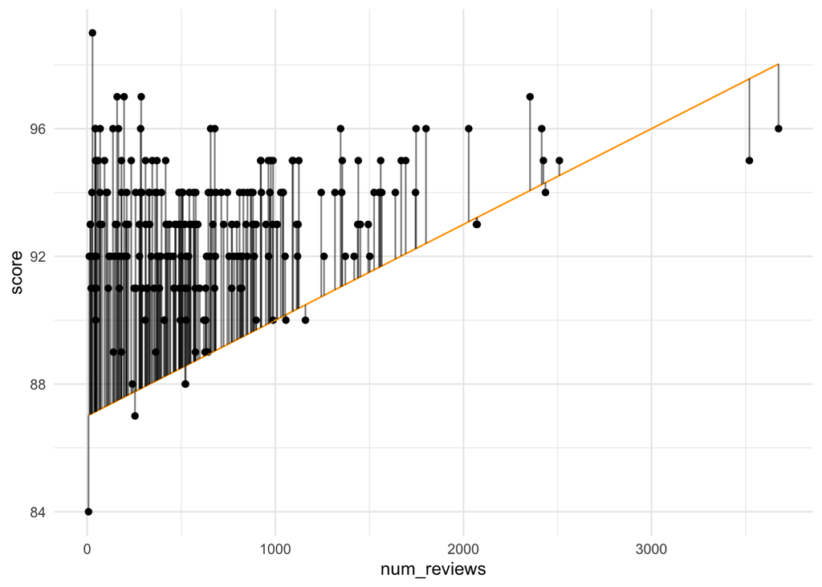

```r
tea %>%
  mutate(score_pred = 87 + num_reviews * 0.003) %>%
  ggplot(aes(num_reviews, score)) +
    geom_point() +
    geom_line(aes(num_reviews, score_pred), color = "orange") +
    geom_segment(aes(xend = num_reviews, yend = score_pred), alpha = 0.5)
```

Notice that this line under-guesses most of the score of teas, particularly if the number of reviews is low.

## Computing the OLS Estimator in R

How can we figure out what the best alpha and beta are for this model? A straightforward way would be to just try a large number of values and see which one minimizes the response. This is largely impractical, and it is better to use an analytical approach, which we can compute in R using the `lm` function.

```r
model <- tea %>%
  lm(score ~ num_reviews, data = .)

summary(model)
```

```
##
## Call:
## lm(formula = score ~ num_reviews, data = .)
##
## Residuals:
##     Min      1Q  Median      3Q     Max
## -8.2762 -1.0497  0.2021  1.2236  6.7044
##
## Coefficients:
##              Estimate Std. Error t value Pr(>|t|)
## (Intercept) 9.227e+01  1.916e-01 481.639  < 2e-16 ***
## num_reviews 9.233e-04  2.126e-04   4.343 2.09e-05 ***
## ---
## Signif. codes:  0 '***' 0.001 '**' 0.01 '*' 0.05 '.' 0.1 ' ' 1
##
## Residual standard error: 1.915 on 236 degrees of freedom
## Multiple R-squared:  0.07399,    Adjusted R-squared:  0.07007
## F-statistic: 18.86 on 1 and 236 DF,  p-value: 2.092e-05
```

Notice that I am using the pipe notation here, and signaling that the data set needs to go into the `data` argument with the `.` sign. In a similar way, we can use the predict function to fit predictions for model to our data:

```r
tea %>%
  mutate(score_pred_lm = predict(model, newdata = .)) %>%
  select(score, name, score_pred_lm)
```

```
## # A tibble: 238 x 3
##    score name                score_pred_lm
##    <dbl> <chr>                       <dbl>
##  1    96 irish_breakfast              95.7
##  2    95 earl_grey_bravo              95.5
##  3    95 golden_monkey                93.3
##  4    96 black_dragon_pearls          93.9
##  5    95 yunnan_noir                  93.2
##  6    95 earl_grey_moonlight          94.6
##  7    93 english_breakfast            93.2
##  8    92 keemun_concerto              92.7
##  9    95 yunnan_gold                  93.3
## 10    94 ceylon_sonata                93.7
## # … with 228 more rows
```

And now plot the fitted values.

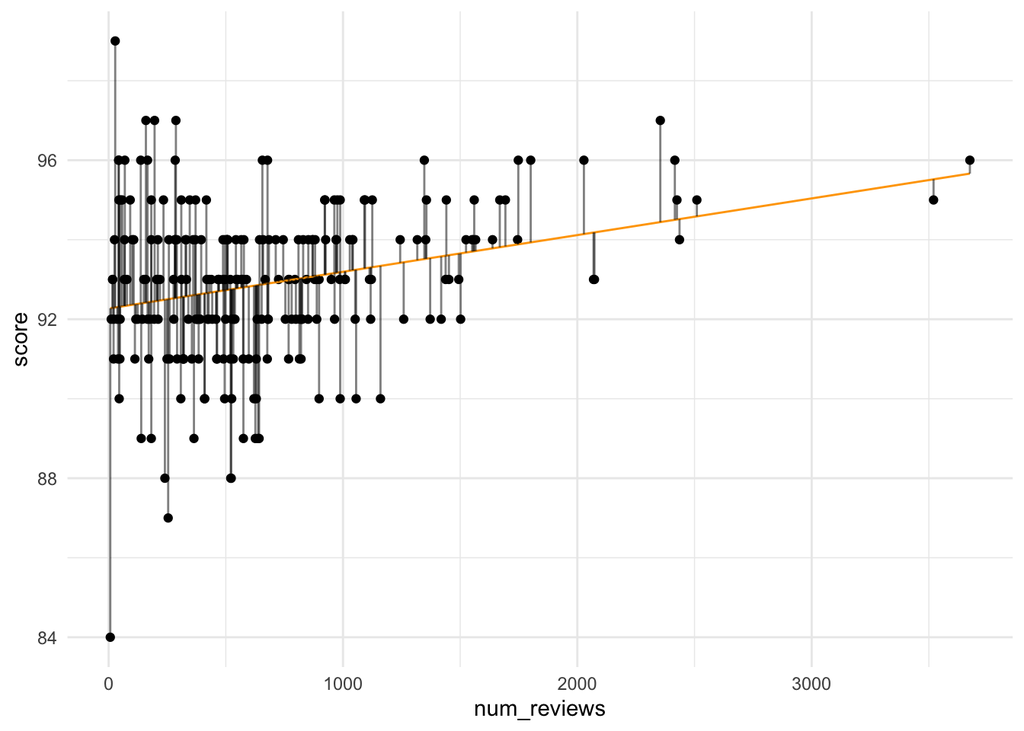

```r
tea %>%
  mutate(score_pred_lm = predict(model, newdata = .)) %>%
  ggplot(aes(num_reviews, score)) +
    geom_point() +
    geom_line(aes(num_reviews, score_pred_lm), color = "orange") +
    geom_segment(aes(xend = num_reviews, yend = score_pred_lm), alpha = 0.5)
```

Does it visually correspond to where you would expect the best fit line to run?

## Evaluating models

How should be evaluate the predictive ability of a model? The method of ordinary least squares suggests that we should consider the sum of squared errors. A challenge with this is that the value of a sum will grow in proportion to how many observations there are. This makes it hard to compare results across data sources and subsets. A simple solution is to use the average value of the squared errors, known as the mean squared error or MSE:

```r
tea %>%
  mutate(score_pred_lm = predict(model, newdata = .)) %>%
  summarize(mse = mean((score - score_pred_lm)^2))
```

```
## # A tibble: 1 x 1
##     mse
##   <dbl>
## 1  3.64
```

This works as a general measurement of error, but the units are a bit strange as they are given in squared scores. A simple solution to this exists by taking the square root of the MSE, resulting in the root mean squared error (RMSE):

```r
tea %>%
  mutate(score_pred_lm = predict(model, newdata = .)) %>%
  summarize(rmse = sqrt(mean((score - score_pred_lm)^2)))
```

```
## # A tibble: 1 x 1
##    rmse
##   <dbl>
## 1  1.91
```

You’ll find references to the RMSE through the literature on machine learning as it is by far the most common measurement for predictiveness of continuous responses.

```r
tea %>%
  mutate(score_pred_const = mean(score)) %>%
  summarize(rmse = sqrt(mean((score - score_pred_const)^2)))
```

```
## # A tibble: 1 x 1
##    rmse
##   <dbl>
## 1  1.98
```

So, we have improved on the baseline model, but not by a large amount. Note that if you are familiar with the standard deviation, the RMSE of the mean is *almost* equal to the standard deviation of the errors.

## Multivariate linear regression

The linear regression model I just introduced is known as simple linear regression because there is only one explanatory variable. We can easy consider multivariate models; for instance, we can be write a two variable model mathematically as follows:

$$Y_i = \alpha + \beta * X_i + \gamma * Z_i + \epsilon_i, \quad mean(\epsilon_i) = 0$$

The geometric interpretation of this is that we have plane in place of the line in the simple linear regression model.

When I teach an applied statistics course, we spend a lot of time working up to multivariate regression models. The interpretation of multivariate models can quickly become quite complex. However, using multivariate models in statistical learning is much easier to understand: each slope coefficient (beta and gamma here) corresponds to a weight placed on how much the response changes with each predictor variable.

Fitting multivariate models is also quite easy with the `lm` function. Simply add the variables together that you would like to use for prediction. Here we use both the number of reviews and the price of the tea:

```r
model <- tea %>%
  lm(score ~ num_reviews + price, data = .)

summary(model)
```

```
##
## Call:
## lm(formula = score ~ num_reviews + price, data = .)
##
## Residuals:
##     Min      1Q  Median      3Q     Max
## -8.7081 -0.9658  0.1446  1.1335  7.1378
##
## Coefficients:
##              Estimate Std. Error t value Pr(>|t|)
## (Intercept) 9.161e+01  2.388e-01 383.553  < 2e-16 ***
## num_reviews 1.231e-03  2.168e-04   5.678 4.01e-08 ***
## price       1.816e-02  4.169e-03   4.356 1.98e-05 ***
## ---
## Signif. codes:  0 '***' 0.001 '**' 0.01 '*' 0.05 '.' 0.1 ' ' 1
##
## Residual standard error: 1.846 on 235 degrees of freedom
## Multiple R-squared:  0.1432, Adjusted R-squared:  0.1359
## F-statistic: 19.64 on 2 and 235 DF,  p-value: 1.3e-08
```

```r
tea %>%
  mutate(score_pred_lm = predict(model, newdata = .)) %>%
  summarize(rmse = sqrt(mean((score - score_pred_lm)^2)))
```

```
## # A tibble: 1 x 1
##    rmse
##   <dbl>
## 1  1.83
```

## Training and Validation Data

So far we have been using our tea data set to build a predictive model and then to evaluate it. We are cheating a bit here, because it’s fairly easy to make predictions about something we have already seen. In predictive modeling, a standard way of avoiding this is to randomly split our data set into two different groups: a training set and a validation set (other terms are sometimes used, but these are what I will call them). We can then fit our model parameters using the training data and then validate how well our model fits on the validation set.

Here is some code to add an indicator variable to the data splitting the data into a training and validation observations. The seed makes sure that the split is consistent (each time I run it, it will create the same split); I have chosen to split the data into 60% training and 40% validation.

```r
set.seed(1)

tea <- read_csv(file.path("data", "tea.csv")) %>%
  mutate(train_id = if_else(runif(n()) < 0.6, "train", "valid"))
tea
```

```
## # A tibble: 238 x 6
##    score name                type  price num_reviews train_id
##    <dbl> <chr>               <chr> <dbl>       <dbl> <chr>
##  1    96 irish_breakfast     black    10        3675 valid
##  2    95 earl_grey_bravo     black    10        3520 valid
##  3    95 golden_monkey       black    27        1125 train
##  4    96 black_dragon_pearls black    32        1748 train
##  5    95 yunnan_noir         black    17         988 train
##  6    95 earl_grey_moonlight black    10        2510 valid
##  7    93 english_breakfast   black    17        1008 train
##  8    92 keemun_concerto     black    17         499 valid
##  9    95 yunnan_gold         black    40        1094 train
## 10    94 ceylon_sonata       black    12        1525 valid
## # … with 228 more rows
```

And now we will fit the linear regression model using just those observations that are in the training data set:

```r
model <- tea %>%
  filter(train_id == "train") %>%
  lm(score ~ num_reviews + price, data = .)

summary(model)
```

```
##
## Call:
## lm(formula = score ~ num_reviews + price, data = .)
##
## Residuals:
##     Min      1Q  Median      3Q     Max
## -4.2551 -1.0145  0.0321  1.0973  6.9775
##
## Coefficients:
##              Estimate Std. Error t value Pr(>|t|)
## (Intercept) 9.176e+01  2.889e-01 317.659  < 2e-16 ***
## num_reviews 1.274e-03  2.875e-04   4.431 1.87e-05 ***
## price       1.874e-02  4.392e-03   4.265 3.64e-05 ***
## ---
## Signif. codes:  0 '***' 0.001 '**' 0.01 '*' 0.05 '.' 0.1 ' ' 1
##
## Residual standard error: 1.654 on 141 degrees of freedom
## Multiple R-squared:  0.165,  Adjusted R-squared:  0.1532
## F-statistic: 13.93 on 2 and 141 DF,  p-value: 3.008e-06
```

Notice that the coefficients are slightly different. Then, we will predict the model on the entire data set and find the RMSE on both the training and validation data:

```r
tea %>%
  mutate(score_pred_lm = predict(model, newdata = .)) %>%
  group_by(train_id) %>%
  summarize(rmse = sqrt(mean((score - score_pred_lm)^2)))
```

```
## # A tibble: 2 x 2
##   train_id  rmse
##   <chr>    <dbl>
## 1 train     1.64
## 2 valid     2.13
```

As we might expect, the model fits the training data much better than the validation data.